# Landmark Examples

Yara Skaf

1/28/2022

## Example 1: Basic Illustration

This is one of the simplest possible examples that illustrates the major definitions and the differences between the maxmin and lastfirst procedures. Let $X = \{a,b,c,d\}$ as shown below and equip $X$ with the standard Euclidean metric. Note that $X$ is *not* Hausdorff since the points $c$ and $d$ are indistinguishable since they both have a value of $4$, meaning they cannot be separated by open sets.

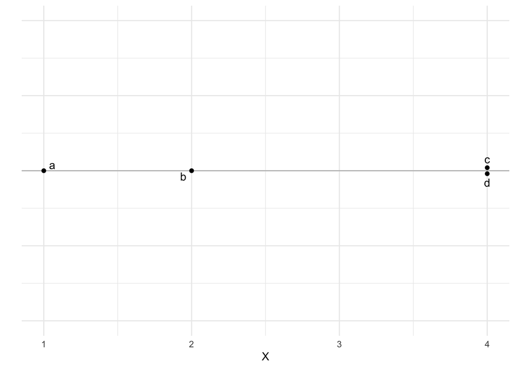

The two procedures generate the same set of landmark points if the seed is chosen to be $\ell_0 = a$. However, the order of landmark selection is different if the seed point is chosen from the minmax or firstlast set.

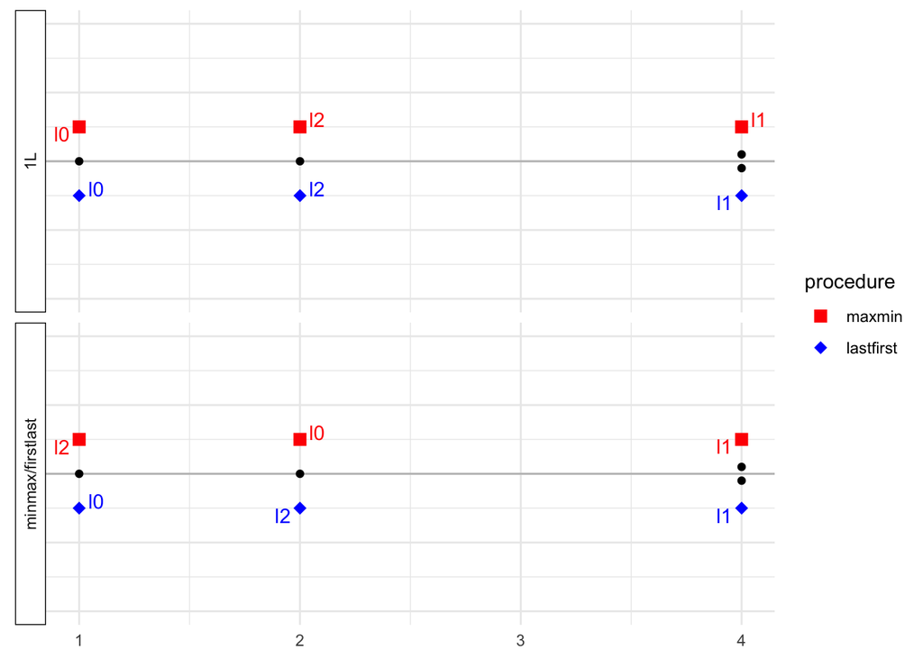

## Example 2: Variable Density

Let $X$ be the data set shown along the $x$-axis in the plot below below and equip $X$ with the standard Euclidean metric. The density of points in $X$ is shown on the $y$-axis– note that this density is highest near $x=0$, also high near $x=1$, and significantly lower in between these two values..

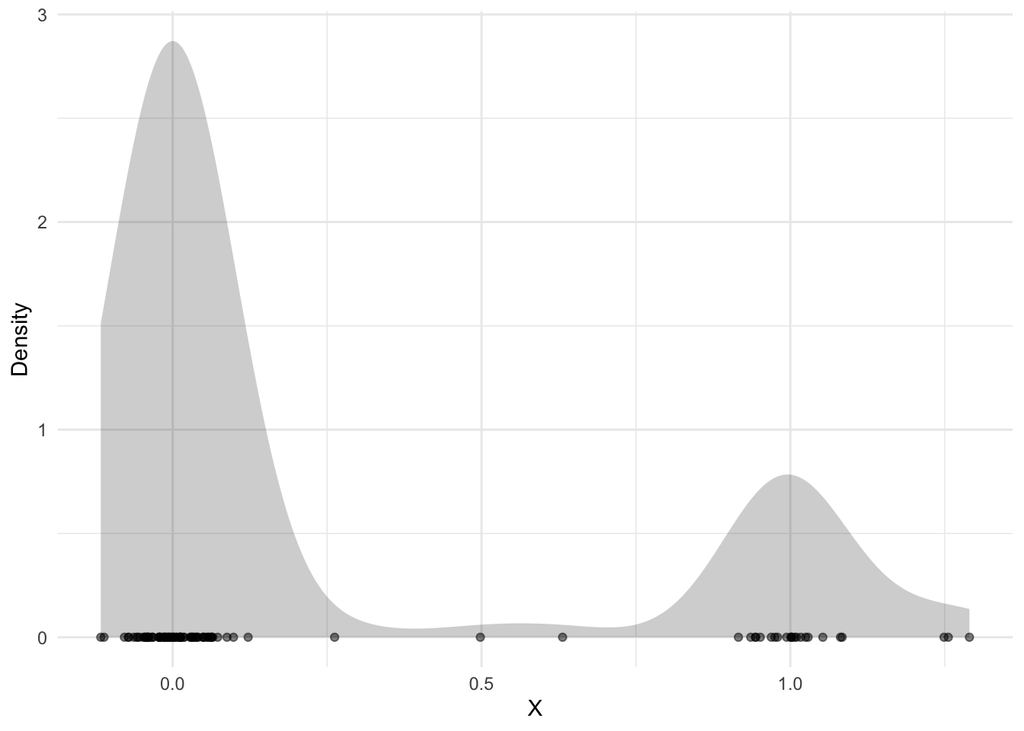

Observe that calculating the first few landmark points of $X$ gives different results with each procedure:

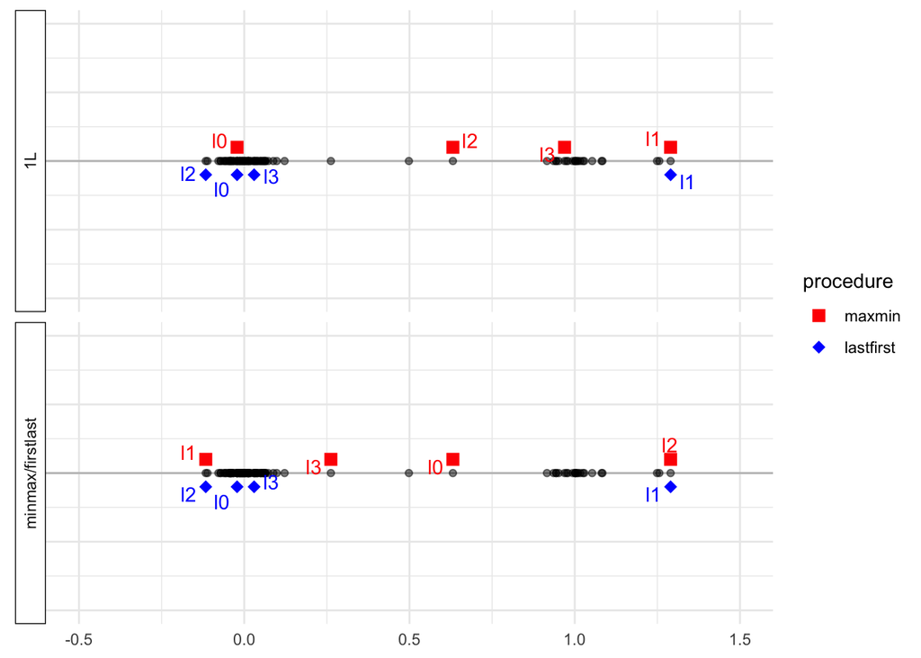

We can also examine the cover sets generated by these landmarks for each procedure (maxmin is on the left, lastfirst on the right, both use the minmax/lastfirst seed……I haven’t come up with a great way of visualizing these yet, so this is just a preliminary idea):

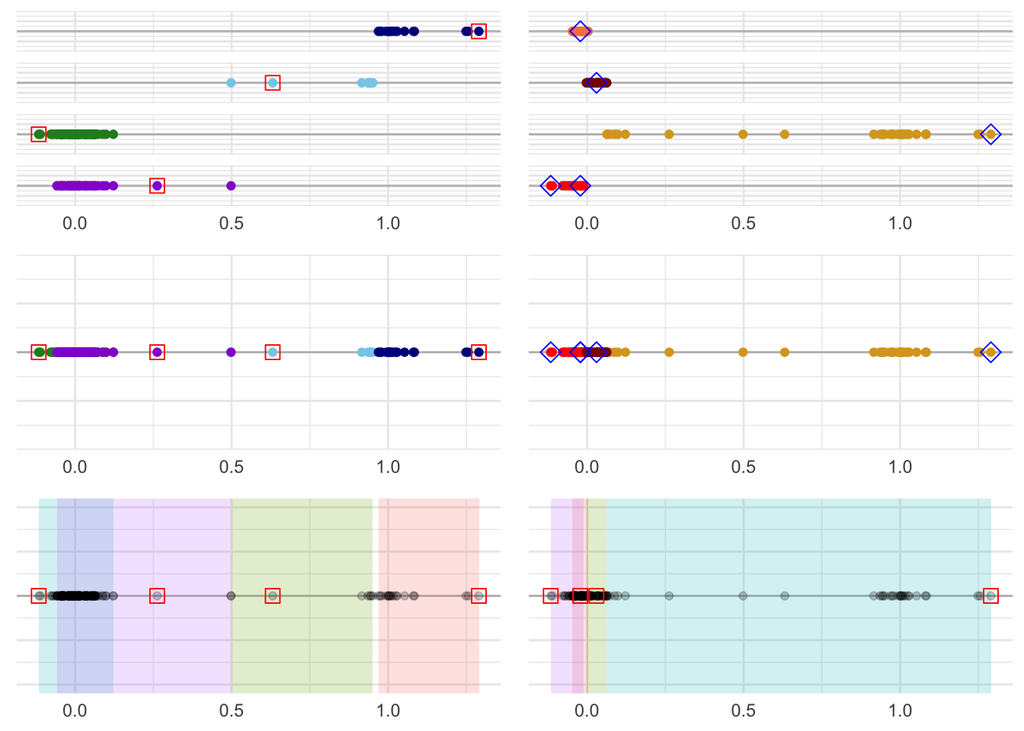

## Example 3: Necklace Sampler

This data set provides a clear, 2-dimensional example of a situation where the differences between the maxmin and lastfirst algorithms result in significant differences between the two landmark sets, and thus between the resulting covers. Let $X$ be the data set shown below equipped with the standard Euclidean metric.

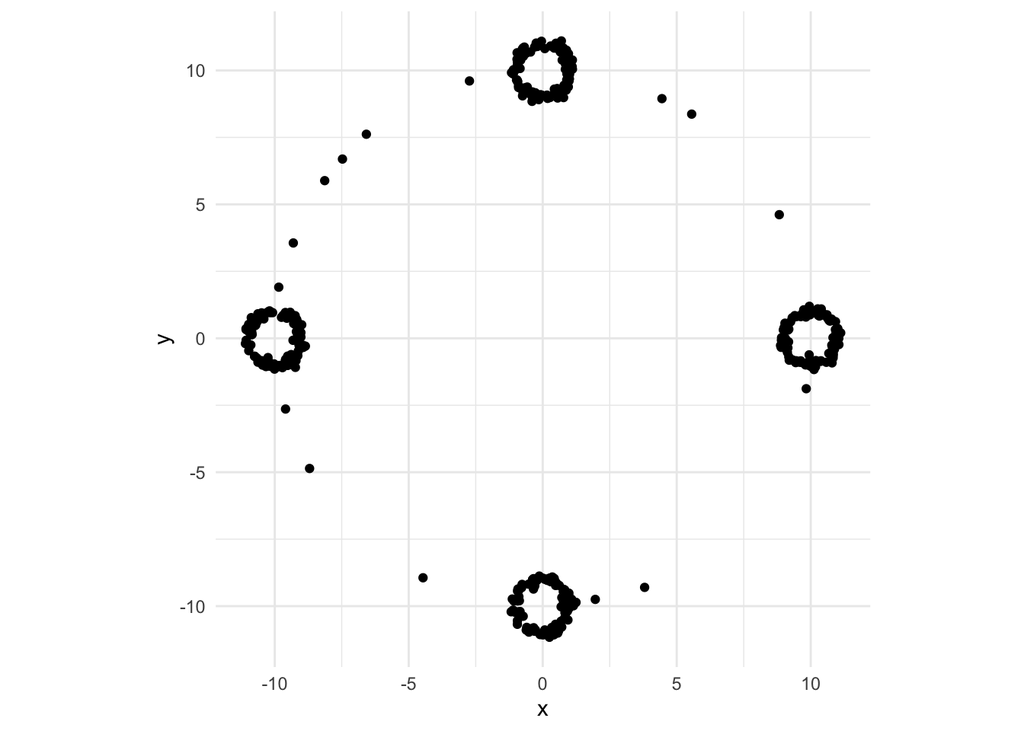

Observe that calculating the first few landmark points of $X$ gives different results with each procedure: While maxmin generates landmarks evenly across both dense and sparse regions of the necklace, lastfirst concentrates landmarks in dense regions and generates fewer in sparse regions. The patterns, and the procedures, may be appropriate for different settings: If the necklace is understood as a biased sample from a single circular shape, each region of which is of equal interest, then maxmin generates a more desirable sample. If, instead, the density of the sample is believed to reflect the density of an underlying population, then the lastfirst sample will be more useful. While many techniques could be used for this purpose, maxmin and lastfirst have the advantage of being deterministic up to the seed point and co-location.

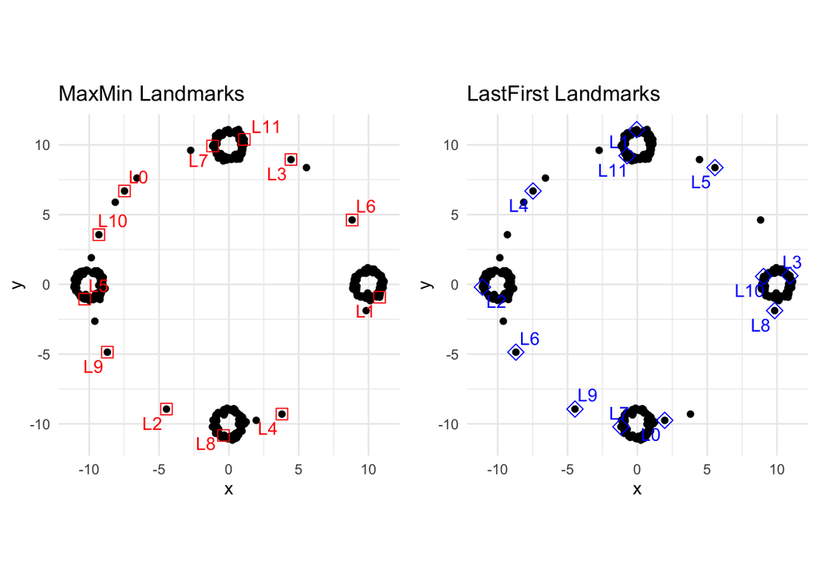